# MTH6139 Time Series

Coursework 1: Forecasting UK Annual GDP with Meta Prophet

Saifullah Yaqoob

March 2026

# Section 1: Introduction

This project studies the evolution of United Kingdom Annual GDP over time and applies Meta Prophet to produce forecasts.

GDP measures the total value of goods and services produced in a country. Understanding its long-run behaviour is in understanding how well an economy is doing.

The aim is: to explore the trend in GDP, check whether the series is smooth or volatile, apply a Prophet model and generate a forecast.

## 1.1 Data and Setup

The data used in this report is annual UK GDP. The series is arranged in the format required by Prophet, with ds for the date column and y for the variable being forecast.

```r
library(WDI)
library(dplyr)
```

```r
library(ggplot2)
library(prophet)
gdp_raw <- WDI(
  country = "GB",
  indicator = "NY.GDP.MKTP.CD",
  start = 1960,
  end = 2024
)

gdp_data <- gdp_raw %>%
  select(year, NY.GDP.MKTP.CD) %>%
  rename(y = NY.GDP.MKTP.CD) %>%
  mutate(ds = as.Date(paste0(year, "-01-01"))) %>%
  select(ds, y) %>%
  arrange(ds) %>%
  filter(!is.na(y))

head(gdp_data)
```

```
##           ds            y
## 1 1960-01-01  73233967692
## 2 1961-01-01  77741965703
## 3 1962-01-01  81247564157
## 4 1963-01-01  86561961812
## 5 1964-01-01  94407558351
## 6 1965-01-01 101824755079
```

## 1.2 Exploratory Analysis

The first plot shows GDP on the original scale.

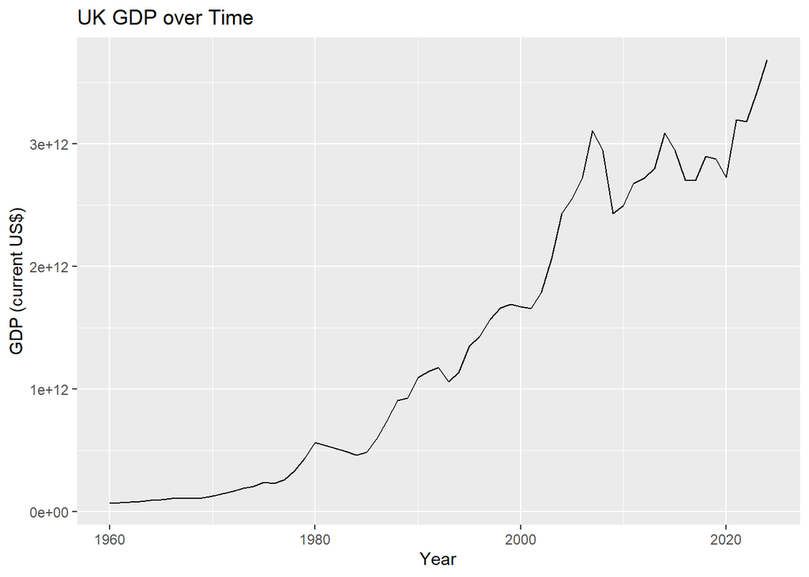

```r
ggplot(gdp_data, aes(x = ds, y = y)) +
  geom_line() +
  labs(
    title = "UK GDP over Time",
    x = "Year",
    y = "GDP (current US$)"
  )
```

## 1.3 Log transformation

A logarithmic transformation is useful because proportional growth is easier to interpret than absolute growth.

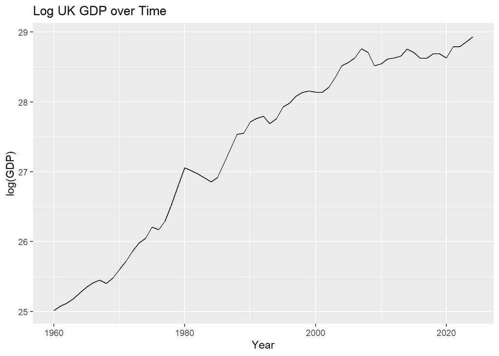

```r
gdp_data <- gdp_data %>%
  mutate(y_log = log(y))

ggplot(gdp_data, aes(x = ds, y = y_log)) +
  geom_line() +
  labs(
    title = "Log UK GDP over Time",
    x = "Year",
    y = "log(GDP)"
  )
```

After applying a logarithmic transformation, the series looks smoother and more stable. The trend now appears closer to a straight line.This indicates that GDP growth may be approximately exponential over time.Because the log series is smoother, it may be more suitable for forecasting.

## 1.4 Linear Trend Check

As a simple benchmark, I fit a linear regression on the log of GDP against time.

```r
gdp_data <- gdp_data %>%
  mutate(time_index = 1:n())

linear_model <- lm(y_log ~ time_index, data = gdp_data)
summary(linear_model)
```

```
##
## Call:
## lm(formula = y_log ~ time_index, data = gdp_data)
##
## Residuals:
##      Min       1Q   Median       3Q      Max
## -0.57376 -0.27420 -0.00319  0.28900  0.47490
##
## Coefficients:
##              Estimate Std. Error t value Pr(>|t|)
## (Intercept) 25.218135   0.080263  314.19   <2e-16 ***
## time_index   0.065389   0.002114   30.93   <2e-16 ***
## ---
## Signif. codes:  0 '***' 0.001 '**' 0.01 '*' 0.05 '.' 0.1 ' ' 1
##
## Residual standard error: 0.3198 on 63 degrees of freedom
## Multiple R-squared:  0.9382, Adjusted R-squared:  0.9372
## F-statistic: 956.4 on 1 and 63 DF,  p-value: < 2.2e-16
```

The regression confirms a positive relationship between time and log GDP.This suggests that GDP has grown steadily over the long run.The linear regression is not the final forecasting model.It is only used to understand the general trend in the data.

# Section 2: Forecasting GDP Using Prophet

Prophet is used here mainly as a trend forecasting tool.

Since the data is annual, I switch off daily, weekly and yearly seasonality. For annual GDP, the main feature of interest is the trend rather than seasonal behaviour.

```r
gdp_prophet_log <- gdp_data %>%
  select(ds, y = y_log)

gdp_model_log <- prophet(
  gdp_prophet_log,
  yearly.seasonality = FALSE,
  weekly.seasonality = FALSE,
  daily.seasonality = FALSE
)
```

I then generate a forecast for 10 years ahead.

```r
future_gdp <- make_future_dataframe(
  gdp_model_log,
  periods = 10,
  freq = "year"
)

forecast_gdp <- predict(gdp_model_log, future_gdp)
```

## 2.1 Forecast Results

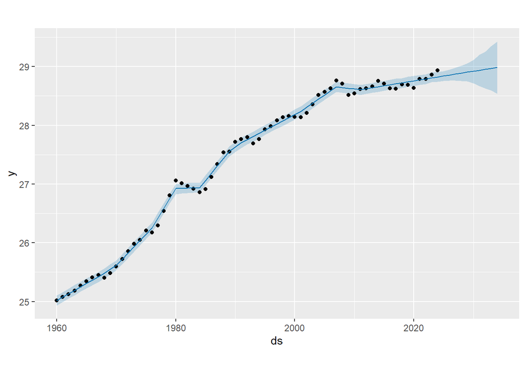

```r
plot(gdp_model_log, forecast_gdp)
```

```r
forecast_output <- forecast_gdp %>%
  select(ds, yhat, yhat_lower, yhat_upper) %>%
  mutate(
    yhat = exp(yhat),
    yhat_lower = exp(yhat_lower),
    yhat_upper = exp(yhat_upper)
  )

tail(forecast_output, 12)
```

```
##            ds         yhat   yhat_lower   yhat_upper
## 64 2023-01-01 3.240014e+12 3.011230e+12 3.558134e+12
## 65 2024-01-01 3.293905e+12 3.036221e+12 3.582215e+12
## 66 2025-01-01 3.348843e+12 3.072777e+12 3.625335e+12
## 67 2026-01-01 3.404544e+12 3.090540e+12 3.728079e+12
## 68 2027-01-01 3.461171e+12 3.106938e+12 3.865388e+12
## 69 2028-01-01 3.518740e+12 3.086841e+12 3.981874e+12
## 70 2029-01-01 3.577428e+12 3.050037e+12 4.162658e+12
## 71 2030-01-01 3.636930e+12 2.969192e+12 4.423816e+12
## 72 2031-01-01 3.697423e+12 2.825971e+12 4.814166e+12
## 73 2032-01-01 3.758921e+12 2.715598e+12 5.062036e+12
## 74 2033-01-01 3.821615e+12 2.618028e+12 5.563351e+12
## 75 2034-01-01 3.885179e+12 2.471234e+12 6.049854e+12
```

These values represent predicted GDP levels.

# Section 3: Discussion

The analysis shows that UK GDP has a strong positive long-run trend.

The original series is not perfectly smooth because economic shocks can affect growth. However, the log transformation makes the trend more stable.

Prophet provides a simple way to extend this trend into the future. The model assumes that historical growth patterns will continue.

Limitations include are: annual data contains relatively few observations, structural economic changes are not explicitly modelled and uncertainty increases for longer forecast horizons

# Section 4: Conclusion

This project explored UK GDP using time series methods and the Prophet forecasting tool.

Key findings in the coursework:

GDP shows a clear upward long-run trend, the log transformation produces a smoother series, Prophet generates a reasonable trend-based forecast, forecast uncertainty increases over time